# **MATH 237 Project 1: Ames Housing Price Analysis**

By: Amber Chatton

### Objectives:

This project investigates the main factors that influence house prices. Comparing how features like neighborhood, overall quality, and year built impact the sale price of a house.

This information is benifital to homebuyers, sellers, and builders that are interested in pricing trends in the Ames, Iowa area.

### Research Questions:

1. What are the most important features that influence house prices?
2. Do newer houses sell more than older houses, when controlling all other variables?
3. Which neighborhoods have the highest average house prices, and what features make that difference?

These questions guide the analysis throughout the project and frame the stages of data wrangling, exploratory data analysis, and modeling.

### Dataset Description:

The Ames Housing Dataset contains information describing the sale of housing property in Ames, Iowa from 2006 to 2010. It consists of 1460 observations and 80 features describing home characteristics. However, it may not be generalized to other regions since the data comes from only Ames, Iowa.

**Data Source:**  
Kaggle https://www.kaggle.com/c/house-prices-advanced-regression-techniques/data

The original data source and description are presented in this [paper](https://jse.amstat.org/v19n3/decock.pdf).

```python
# Import libraries
import pandas as pd
import numpy as np
import matplotlib.pyplot as plt
import seaborn as sns
from sklearn.linear_model import LinearRegression
from sklearn.model_selection import train_test_split
from sklearn.metrics import r2_score, mean_squared_error
from sklearn.preprocessing import StandardScaler

# Setting up my polotting and visualization
plt.style.use('default')
sns.set_palette("husl")
plt.rcParams['figure.figsize'] = (10, 6)
plt.rcParams['font.size'] = 12

pd.set_option('display.width', 200)
```

# Data Wrangling

## Part 1: Load the dataset into Python.

## Part 2: Check for missing values and handle them.

## Part 3: Convert categorical data types if needed.

## Part 4: Create new features like house age that will help me explore more.

## Part 1 : Load the dataset into Python

```python
# Part 1 : Load the dataset into Python

# Connect to Google Drive
from google.colab import drive
drive.mount('/content/drive')

# Load data uding pandas
housing = pd.read_csv('/content/drive/My Drive/Math237Fall25/Datasets/ames-housing-train.csv')

print(f"Dataset shape: {housing.shape}")
print(f"Columns: {list(housing.columns)}")
```

```
Dataset shape: (1460, 81)
Columns: ['Id', 'MSSubClass', 'MSZoning', 'LotFrontage', 'LotArea', 'Street', 'Alley', 'LotShape', 'LandContour', 'Utilities', 'LotConfig', 'LandSlope', 'Neighborhood', 'Condition1', 'Condition2', 'BldgType', 'HouseStyle', 'OverallQual', 'OverallCond', 'YearBuilt', 'YearRemodAdd', 'RoofStyle', 'Roof…
```

```python
housing.info()
```

```
<class 'pandas.core.frame.DataFrame'>
RangeIndex: 1460 entries, 0 to 1459
Data columns (total 81 columns):
 #   Column         Non-Null Count  Dtype
---  ------         --------------  -----
 0   Id             1460 non-null   int64
 1   MSSubClass     1460 non-null   int64
 2   MSZoning       1460 non-null   object
 3   LotFrontage    1201 non-null   float64
 4   LotArea        1460 non-null   int64
 5   Street         1460 non-null   object
 6   Alley          91 non-null     object
 7   LotShape       1460 non-null   object
 8   LandContour    1460 non-null   object
 9   Utilities      1460 non-null   object
```

[output cut: 73 more lines]

```python
# Dropping non conceptually related features
housing = housing.drop(['Id','MoSold','SaleType','SaleCondition',
                        'Utilities','Street','LandSlope',
                        'Condition2','MiscVal','Alley'], axis=1)
housing.shape
```

```
(1460, 71)
```

After reviewing all 79 columns in the Ames Housing dataset, I identified several features that do not conceptually relate to my research questions about house features, age, and neighborhood price differences. These columns describe identifiers, transaction details, or administrative information rather than physical attributes of the property. Since they do not help answer my research questions, I removed them before conducting any missing value analysis, EDA, or modeling.

The following columns were dropped:

- **Administrative / ID:** `Id` — identifier only, no analytical meaning.
- **Transaction Details:** `MoSold`, `SaleType`, `SaleCondition` — describe timing or sale terms, not home features.
- **Infrastructure (almost constant):** `Utilities`, `Street` — little variation across homes.
- **Minor Site Details:** `LandSlope`, `Condition2` — minimal conceptual relevance to price or age.
- **Extra / Redundant:** `MiscVal`, `Alley` — either duplicate or describe external access, not the house itself.

Removing these features allows the analysis to focus only on features that describe the homes themselves like structure, quality, age, and neighborhood which directly support my project objectives.

## Part 2: Check for missing values and handle them.

To Properly manage missing data, it is important to first examine it. Identify what is missing and consider possible reasons for these missing values.

```python
# Check for missing data
print("Columns with missing values:\n")
missing_counts = housing.isnull().sum()
missing_counts = missing_counts[missing_counts > 0] # Only show columns that have missing values
print(missing_counts)
```

```
Columns with missing values:

LotFrontage      259
MasVnrType       872
MasVnrArea         8
BsmtQual          37
BsmtCond          37
BsmtExposure      38
BsmtFinType1      37
BsmtFinType2      38
Electrical         1
FireplaceQu      690
GarageType        81
GarageYrBlt       81
GarageFinish      81
GarageQual        81
GarageCond        81
PoolQC          1453
Fence           1179
MiscFeature     1406
dtype: int64
```

```python
complete_cases = len(housing.dropna())
print(f"Complete cases: {complete_cases} out of {len(housing)}")
```

```
Complete cases: 1 out of 1460
```

After droping non conceptually related features, we move on to handling missing data. When checking for the total number of complete cases in the dataset it returned 1 complete case out of 1460 total overvations.

This means that only one record in the dataset has all remaining 71 features fully filled in, and all others have at least one missing value.

Since droping all rows will missing data would essentially remove the entire dataset, I will instead handle missing values by each individual column. This approach preserves the dataset's integrity while allowing for accurate analysis and modeling.

### Handling Missing LotFrontage Values

To clarify what each `LotConfig` value represents, I refrenced the original paper. According to original paper titled “Ames, Iowa: Alternative to the Boston Housing Data as an End of Semester Regression Project.”, where the Ames Housing dataset comes from, the categories of the LotConfig features are defined as follows:

- Inside: Lot located inside a block
- Corner: Lot located at the intersection of two streets
- CulDSac: Lot located within a cul-de-sac
- FR2: Frontage on two sides of property
- FR3: Frontage on three sides of property

To preserve data integrity, I created a flag column `StructuralLot` to identify these cases. For non-structural lots (`Inside`, `Corner`), I imputed missing `LotFrontage` values using the median frontage within each `Neighborhood`. This approach mirrors the strategy used in our penguin notebook, where we applied species-specific logic to impute missing `sex` values.

By selectively imputing and flagging, I avoid over-imputation and maintain transparency in how missing data is handled.

```python
# Check if missing LotFrontage is connected to a certain LotConfig
housing.groupby('LotConfig')['LotFrontage'].apply(lambda x: x.isnull().mean()).sort_values(ascending=False)

# Step 1: Flag structural lots
structural_types = ['CulDSac', 'FR2', 'FR3']
housing['StructuralLot'] = housing['LotConfig'].isin(structural_types)

# Step 2: Create a copy of LotFrontage for imputation
housing['LotFrontage_imputed'] = housing['LotFrontage']

# Step 3: Impute LotFrontage only for non-structural lots using median by Neighborhood
non_structural = housing['StructuralLot'] == False
housing.loc[non_structural, 'LotFrontage_imputed'] = (
    housing[non_structural]
    .groupby('Neighborhood')['LotFrontage']
    .transform(lambda x: x.fillna(x.median()))
)

# Step 4: Flag rows that were imputed
housing['LotFrontage_was_imputed'] = housing['LotFrontage'].isnull() & ~housing['StructuralLot']
```

### Handling Missing MasVnrType Values

`MasVnrType` describes the type of masonry veneer on the house. Before imputing missing values, I checked whether these cases also had `MasVnrArea` equal to 0. If so, it likely indicates that no veneer was applied, and the missing value is not due to data entry error but rather reflects absence.

To confirm this, I examined the rows where `MasVnrType` was missing and found that **859 out of 872** had `MasVnrArea` equal to 0. This suggests that the missingness is **not random**, but instead **structural**.

Therefore, I filled missing `MasVnrType` values with `'None'` to reflect the absence of a veneer, rather than imputing the mode.

Although 13 of the missing `MasVnrType` rows had nonzero `MasVnrArea`, I included them in the `'None'` category for consistency and to avoid over imputation. These cases likely reflect incomplete records rather than true veneer presence.

```python
# Step 1: Count missing MasVnrType
missing_masvnr = housing['MasVnrType'].isnull().sum()
print(f"Missing MasVnrType values: {missing_masvnr}")

# Step 2: Check how many of those have MasVnrArea == 0
mask = housing['MasVnrType'].isnull() & (housing['MasVnrArea'] == 0)
print(f"Missing MasVnrType with MasVnrArea == 0: {mask.sum()} out of {missing_masvnr}")

# Step 3: Fill missing MasVnrType with 'None' to reflect absence
housing['MasVnrType'] = housing['MasVnrType'].fillna('None')

# Step 4: Show updated distribution
print("\nUpdated MasVnrType distribution:")
print(housing['MasVnrType'].value_counts(dropna=False))
```

```
Missing MasVnrType values: 872
Missing MasVnrType with MasVnrArea == 0: 859 out of 872

Updated MasVnrType distribution:
MasVnrType
None       872
BrkFace    445
Stone      128
BrkCmn      15
Name: count, dtype: int64
```

### Handling Missing MasVnrArea Values

Using the logic established above for `MasVnrType`, I treated missing `MasVnrArea` values as structural absence when `MasVnrType == 'None'`. In those cases, I filled `MasVnrArea` with 0 to reflect that no masonry veneer was applied.

For any remaining missing values where `MasVnrType` was not `'None'`, I imputed the median veneer area. This preserves consistency across both features and avoids over imputation.

```python
# Step 1: Fill MasVnrArea with 0 where MasVnrType is 'None'
housing.loc[housing['MasVnrType'] == 'None', 'MasVnrArea'] = 0

# Step 2: Fill remaining missing MasVnrArea with median
housing['MasVnrArea'] = housing['MasVnrArea'].fillna(housing['MasVnrArea'].median())

# Step 3: Confirm no missing values remain
print("Remaining missing MasVnrArea:", housing['MasVnrArea'].isnull().sum())
```

```
Remaining missing MasVnrArea: 0
```

### Handling Missing Basement Features

Several basement related columns (`BsmtQual`, `BsmtCond`, `BsmtExposure`, `BsmtFinType1`, `BsmtFinType2`) have missing values. Based on domain knowledge and inspection of the data, these missing values likely indicate that the house has **no basement** not that the data was lost or entered incorrectly.

This mirrors the logic used for `MasVnrType`, where missing values paired with zero veneer area signaled structural absence. To preserve this meaning, I filled missing basement values with `'None'`, indicating that the feature does not exsist rather than unknown.

This approach avoids over imputation and maintains transparency.

```python
# Step 1: Define basement-related columns
bsmt_cols = ['BsmtQual', 'BsmtCond', 'BsmtExposure', 'BsmtFinType1', 'BsmtFinType2']

# Step 2: Fill missing values with 'None' to reflect absence
for col in bsmt_cols:
    housing[col] = housing[col].fillna('None')

# Step 3: Confirm no missing values remain
print("Remaining missing values in basement features:")
print(housing[bsmt_cols].isnull().sum())
```

```
Remaining missing values in basement features:
BsmtQual        0
BsmtCond        0
BsmtExposure    0
BsmtFinType1    0
BsmtFinType2    0
dtype: int64
```

### Handling Missing Electrical Values

`Electrical` describes the type of electrical system in the house. Only one value is missing, which suggests random error rather than structural absence. To resolve this, I filled the missing value with the mode, the most common electrical system type. This mirrors our penguin notebook strategy for low-missing categorical features.

```python
# Step 1: Fill missing Electrical value with the mode
housing['Electrical'] = housing['Electrical'].fillna(housing['Electrical'].mode()[0])

# Step 2: Confirm no missing values remain
print("Remaining missing Electrical values:", housing['Electrical'].isnull().sum())
```

```
Remaining missing Electrical values: 0
```

### Handling Missing FireplaceQu Values

`FireplaceQu` describes the quality of the fireplace. To determine whether missing values reflect absence or error, I checked whether these rows also had `Fireplaces == 0`. All of them did, insisting that the missingness is structural and these homes simply do not have fireplaces.

To preserve this meaning, I filled missing values with `'None'`, indicating that the feature is not applicable.

```python
# Step 1: Count missing FireplaceQu values
missing_fireplacequ = housing['FireplaceQu'].isnull().sum()
print(f"Missing FireplaceQu values: {missing_fireplacequ}")

# Step 2: Check how many of those have Fireplaces == 0
mask = housing['FireplaceQu'].isnull() & (housing['Fireplaces'] == 0)
print(f"Missing FireplaceQu with Fireplaces == 0: {mask.sum()} out of {missing_fireplacequ}")

# Step 3: Fill missing FireplaceQu values with 'None' to reflect absence
housing['FireplaceQu'] = housing['FireplaceQu'].fillna('None')

# Step 4: Confirm no missing values remain
print("Remaining missing FireplaceQu values:", housing['FireplaceQu'].isnull().sum())
```

```
Missing FireplaceQu values: 690
Missing FireplaceQu with Fireplaces == 0: 690 out of 690
Remaining missing FireplaceQu values: 0
```

### Handling Missing Garage Features

Garage-related columns (`GarageType`, `GarageYrBlt`, `GarageFinish`, `GarageQual`, `GarageCond`) share identical missingness. To confirm that these missing values reflect absence rather than error, I checked whether the affected rows also had `GarageCars == 0` and `GarageArea == 0`.

All of them did, confirming the hypothesis that the missingness is structural and these homes simply do not have garages. I filled categorical features with `'None'` to reflect absence, and imputed `GarageYrBlt` with the median to preserve numeric consistency.

```python
# Step 1: Count missing values in garage features
garage_cols = ['GarageType', 'GarageYrBlt', 'GarageFinish', 'GarageQual', 'GarageCond']
missing_counts = housing[garage_cols].isnull().sum()
print("Missing values in garage features:")
print(missing_counts)

# Step 2: Check if those rows also have GarageCars == 0 and GarageArea == 0
missing_mask = housing['GarageType'].isnull()
no_garage = housing[missing_mask][['GarageCars', 'GarageArea']]
print("\nGarageCars and GarageArea for rows with missing garage features:")
print(no_garage.value_counts())

# Step 3: Fill categorical garage features with 'None'
garage_cat = ['GarageType', 'GarageFinish', 'GarageQual', 'GarageCond']
for col in garage_cat:
    housing[col] = housing[col].fillna('None')

# Step 4: Fill GarageYrBlt with median
housing['GarageYrBlt'] = housing['GarageYrBlt'].fillna(housing['GarageYrBlt'].median())

# Step 5: Confirm no missing values remain
print("\nRemaining missing values in garage features:")
print(housing[garage_cols].isnull().sum())
```

```
Missing values in garage features:
GarageType      81
GarageYrBlt     81
GarageFinish    81
GarageQual      81
GarageCond      81
dtype: int64

GarageCars and GarageArea for rows with missing garage features:
GarageCars  GarageArea
0           0             81
Name: count, dtype: int64

Remaining missing values in garage features:
GarageType      0
GarageYrBlt     0
GarageFinish    0
GarageQual      0
GarageCond      0
dtype: int64
```

### Handling Missing PoolQC Values

`PoolQC` describes pool quality. To confirm that missing values reflect absence rather than error, I checked whether these rows also had `PoolArea == 0`. All missing `PoolQC` rows had zero pool area, confirming that the missingness is structural and these homes do not have pools.

To preserve this meaning, I filled missing values with `'None'`, indicating that the feature is not applicable.

```python
# Step 1: Count missing PoolQC values
missing_poolqc = housing['PoolQC'].isnull().sum()
print(f"Missing PoolQC values: {missing_poolqc}")

# Step 2: Check how many of those have PoolArea == 0
mask_pool = housing['PoolQC'].isnull() & (housing['PoolArea'] == 0)
print(f"Missing PoolQC with PoolArea == 0: {mask_pool.sum()} out of {missing_poolqc}")

# Step 3: Fill missing PoolQC values with 'None'
housing['PoolQC'] = housing['PoolQC'].fillna('None')

# Step 4: Confirm no missing values remain
print("Remaining missing PoolQC values:", housing['PoolQC'].isnull().sum())
```

```
Missing PoolQC values: 1453
Missing PoolQC with PoolArea == 0: 1453 out of 1453
Remaining missing PoolQC values: 0
```

### Handling Missing Fence Values

`Fence` describes fence quality. To confirm that missing values reflect absence, I inspected the distribution of `Fence` values. Most entries were missing, and the remaining values were sparse and categorical, suggesting that fences are uncommon and missingness reflects absence.

To preserve this meaning, I filled missing values with `'None'`, indicating that the feature is not applicable.

```python
# Step 1: Count missing Fence values
missing_fence = housing['Fence'].isnull().sum()
print(f"Missing Fence values: {missing_fence}")

# Step 2: Inspect value distribution
print("Fence value counts (including missing):")
print(housing['Fence'].value_counts(dropna=False))

# Step 3: Fill missing Fence values with 'None'
housing['Fence'] = housing['Fence'].fillna('None')

# Step 4: Confirm no missing values remain
print("Remaining missing Fence values:", housing['Fence'].isnull().sum())
```

```
Missing Fence values: 1179
Fence value counts (including missing):
Fence
NaN      1179
MnPrv     157
GdPrv      59
GdWo       54
MnWw       11
Name: count, dtype: int64
Remaining missing Fence values: 0
```

### Handling Missing MiscFeature Values

`MiscFeature` captures miscellaneous features like sheds, tennis courts, or other non-standard amenities. To confirm that missing values reflect absence, I inspected the value distribution. Most entries were missing, and the few non-null values were rare features, confirming that missingness is structural.

To preserve this meaning, I filled missing values with `'None'`, indicating that the feature is not applicable.

```python
# Step 1: Count missing MiscFeature values
missing_misc = housing['MiscFeature'].isnull().sum()
print(f"Missing MiscFeature values: {missing_misc}")

# Step 2: Inspect value distribution
print("MiscFeature value counts (including missing):")
print(housing['MiscFeature'].value_counts(dropna=False))

# Step 3: Fill missing MiscFeature values with 'None'
housing['MiscFeature'] = housing['MiscFeature'].fillna('None')

# Step 4: Confirm no missing values remain
print("Remaining missing MiscFeature values:", housing['MiscFeature'].isnull().sum())
```

```
Missing MiscFeature values: 1406
MiscFeature value counts (including missing):
MiscFeature
NaN     1406
Shed      49
Gar2       2
Othr       2
TenC       1
Name: count, dtype: int64
Remaining missing MiscFeature values: 0
```

```python
housing.info()
```

```
<class 'pandas.core.frame.DataFrame'>
RangeIndex: 1460 entries, 0 to 1459
Data columns (total 74 columns):
 #   Column                   Non-Null Count  Dtype
---  ------                   --------------  -----
 0   MSSubClass               1460 non-null   int64
 1   MSZoning                 1460 non-null   object
 2   LotFrontage              1201 non-null   float64
 3   LotArea                  1460 non-null   int64
 4   LotShape                 1460 non-null   object
 5   LandContour              1460 non-null   object
 6   LotConfig                1460 non-null   object
 7   Neighborhood             1460 non-null   object
 8   Condition1               1460 non-null   object
 9   BldgType                 1460 non-null   object
```

[output cut: 66 more lines]

### Refining Features After Handling Missing Data

After fixing missing values and reviewing the dataset again, I examined how each column behaved and whether it conceptually or statistically supported my research questions.  
Some features had little variation, excessive missingness, or did not meaningfully describe house characteristics, age, or neighborhood differences.  
To simplify the analysis and focus on the strongest predictors of housing price, I decided to remove the following columns:

- **RoofMatl**: Nearly all homes share the same roofing material (`CompShg`), providing no useful variation.
- **Heating**: Almost all homes use `GasA`; no meaningful variation for analysis.
- **Electrical**: Dominated by `SBrkr`; redundant for modeling.
- **Functional**: Mostly listed as “Typ,” duplicating condition-related information already captured by `OverallCond`.
- **MiscFeature** and **MiscVal**: Over 95% missing or zero; adds noise without improving insight.
- **PoolQC** and **PoolArea**: Fewer than 1% of homes have pools; statistically insignificant for general analysis.
- **Fence**: Over 80% missing
- **LowQualFinSF**: Nearly all values are zero; no contribution to variance or prediction.
- **3SsnPorch** and **ScreenPorch**: Rare features with minimal impact on price.
- **WoodDeckSF**, **OpenPorchSF**, and **EnclosedPorch**: Weak relationships with `SalePrice` and redundant with overall living area.
- **RoofStyle**: Minimal variation; most are `Gable` or `Hip`.
- **Exterior1st** and **Exterior2nd**: Highly categorical and redundant; outer siding type not part of the research focus.
- **StructuralLot**, **LotFrontage_imputed**, and **LotFrontage_was_imputed**: Helper or engineered columns created during cleaning, not real property features.

After dropping these features, the dataset now focuses on the most relevant housing attributes like structure, quality, age, and neighborhood, which directly aligns with the project’s three research questions.

```python
# RoofMatl: Nearly all homes share the same roofing material
print("RoofMatl value counts:")
print(housing['RoofMatl'].value_counts(dropna=False))

# Heating: Almost all homes use GasA
print("\nHeating value counts:")
print(housing['Heating'].value_counts(dropna=False))

# Electrical: Dominated by SBrkr
print("\nElectrical value counts:")
print(housing['Electrical'].value_counts(dropna=False))

# Functional: Mostly listed as “Typ”
print("\nFunctional value counts:")
print(housing['Functional'].value_counts(dropna=False))

# MiscFeature: Over 95% missing or zero
print("\nMiscFeature missing:", housing['MiscFeature'].isnull().sum())

# PoolQC and PoolArea: Fewer than 1% of homes have pools
print("\nPoolQC missing:", housing['PoolQC'].isnull().sum())
print("PoolArea value counts:")
print(housing['PoolArea'].value_counts())

# Fence: Over 80% missing
print("\nFence missing:", housing['Fence'].isnull().sum())
print("Fence value counts:")
print(housing['Fence'].value_counts(dropna=False))

# LowQualFinSF: Nearly all values are zero
print("\nLowQualFinSF value counts:")
print(housing['LowQualFinSF'].value_counts())

# 3SsnPorch and ScreenPorch: Rare features
print("\n3SsnPorch value counts:")
print(housing['3SsnPorch'].value_counts())
print("\nScreenPorch value counts:")
print(housing['ScreenPorch'].value_counts())

# WoodDeckSF, OpenPorchSF, EnclosedPorch: Weak correlation with SalePrice
print("\nCorrelation with SalePrice:")
print(housing[['WoodDeckSF', 'OpenPorchSF', 'EnclosedPorch', 'SalePrice']].corr()['SalePrice'])

# RoofStyle: Minimal variation
print("\nRoofStyle value counts:")
print(housing['RoofStyle'].value_counts(dropna=False))

# Exterior1st and Exterior2nd: Highly categorical and redundant
print("\nExterior1st value counts:")
print(housing['Exterior1st'].value_counts(dropna=False))
print("\nExterior2nd value counts:")
print(housing['Exterior2nd'].value_counts(dropna=False))

# StructuralLot, LotFrontage_imputed, LotFrontage_was_imputed: Engineered columns
print("\nStructuralLot type:", housing['StructuralLot'].dtype)
print("LotFrontage_imputed missing:", housing['LotFrontage_imputed'].isnull().sum())
print("LotFrontage_was_imputed value counts:")
print(housing['LotFrontage_was_imputed'].value_counts())

columns_to_drop = [
    'RoofMatl', 'Heating', 'Electrical', 'Functional',
    'MiscFeature', 'PoolQC', 'PoolArea', 'Fence',
    'LowQualFinSF', '3SsnPorch', 'ScreenPorch',
    'WoodDeckSF', 'OpenPorchSF', 'EnclosedPorch',
    'RoofStyle', 'Exterior1st', 'Exterior2nd',
    'StructuralLot', 'LotFrontage_imputed', 'LotFrontage_was_imputed'
]


housing.drop(columns=columns_to_drop, inplace=True)
print(f"\nRemaining columns: {housing.shape[1]}")
```

```
RoofMatl value counts:
RoofMatl
CompShg    1434
Tar&Grv      11
WdShngl       6
WdShake       5
Metal         1
Membran       1
Roll          1
ClyTile       1
Name: count, dtype: int64

Heating value counts:
Heating
GasA     1428
GasW       18
Grav        7
Wall        4
OthW        2
Floor       1
Name: count, dtype: int64

Electrical value counts:
Electrical
SBrkr    1335
FuseA      94
FuseF      27
FuseP       3
Mix         1
Name: count, dtype: int64

Functional value counts:
Functional
Typ     1360
Min2      34
Min1      31
Mod       15
Maj1      14
Maj2       5
Sev        1
```

[output cut: 144 more lines]

```
Stone        5
AsphShn      3
Other        1
CBlock       1
Name: count, dtype: int64

StructuralLot type: bool
LotFrontage_imputed missing: 63
LotFrontage_was_imputed value counts:
LotFrontage_was_imputed
False    1264
True      196
Name: count, dtype: int64

Remaining columns: 54
```

```python
housing.info()
```

```
<class 'pandas.core.frame.DataFrame'>
RangeIndex: 1460 entries, 0 to 1459
Data columns (total 54 columns):
 #   Column        Non-Null Count  Dtype
---  ------        --------------  -----
 0   MSSubClass    1460 non-null   int64
 1   MSZoning      1460 non-null   object
 2   LotFrontage   1201 non-null   float64
 3   LotArea       1460 non-null   int64
 4   LotShape      1460 non-null   object
 5   LandContour   1460 non-null   object
 6   LotConfig     1460 non-null   object
 7   Neighborhood  1460 non-null   object
 8   Condition1    1460 non-null   object
 9   BldgType      1460 non-null   object
```

[output cut: 46 more lines]

### Part 3: Convert Categorical Data Types

Many columns in the Ames dataset are stored as `object` types but represent meaningful categories.  
To prepare for encoding and modeling, I first converted all `object` columns to `category` dtype using a loop.  
This improves memory efficiency and makes it easier to apply encoding techniques later.

```python
# Step 1: Identify object columns
object_cols = housing.select_dtypes(include='object').columns.tolist()
print("Object columns to convert:", object_cols)

# Step 2: Convert each column individually
for col in object_cols:
    print(f"Converting '{col}' to category...")
    housing[col] = housing[col].astype('category')

# Step 3: Confirm conversion
print("\nUpdated dtypes for categorical columns:")
for col in object_cols:
    print(f"{col}: {housing[col].dtype}")
```

```
Object columns to convert: ['MSZoning', 'LotShape', 'LandContour', 'LotConfig', 'Neighborhood', 'Condition1', 'BldgType', 'HouseStyle', 'MasVnrType', 'ExterQual', 'ExterCond', 'Foundation', 'BsmtQual', 'BsmtCond', 'BsmtExposure', 'BsmtFinType1', 'BsmtFinType2', 'HeatingQC', 'CentralAir', 'KitchenQua…
Converting 'MSZoning' to category...
Converting 'LotShape' to category...
Converting 'LandContour' to category...
Converting 'LotConfig' to category...
Converting 'Neighborhood' to category...
Converting 'Condition1' to category...
Converting 'BldgType' to category...
Converting 'HouseStyle' to category...
Converting 'MasVnrType' to category...
Converting 'ExterQual' to category...
Converting 'ExterCond' to category...
Converting 'Foundation' to category...
Converting 'BsmtQual' to category...
Converting 'BsmtCond' to category...
Converting 'BsmtExposure' to category...
Converting 'BsmtFinType1' to category...
Converting 'BsmtFinType2' to category...
Converting 'HeatingQC' to category...
Converting 'CentralAir' to category...
Converting 'KitchenQual' to category...
Converting 'FireplaceQu' to category...
Converting 'GarageType' to category...
Converting 'GarageFinish' to category...
Converting 'GarageQual' to category...
Converting 'GarageCond' to category...
Converting 'PavedDrive' to category...

Updated dtypes for categorical columns:
MSZoning: category
LotShape: category
LandContour: category
LotConfig: category
Neighborhood: category
Condition1: category
BldgType: category
HouseStyle: category
MasVnrType: category
ExterQual: category
ExterCond: category
Foundation: category
BsmtQual: category
BsmtCond: category
BsmtExposure: category
BsmtFinType1: category
BsmtFinType2: category
HeatingQC: category
CentralAir: category
KitchenQual: category
FireplaceQu: category
GarageType: category
GarageFinish: category
GarageQual: category
GarageCond: category
PavedDrive: category
```

### Part 4: Create New Features

These features are designed to improve interpretability and model performance by capturing meaningful relationships.

```python
# Create a copy to preserve the original dataset
housing_enhanced = housing.copy()

# Step 1: House age at time of sale
housing_enhanced['HouseAge'] = housing_enhanced['YrSold'] - housing_enhanced['YearBuilt']

# Step 2: Years since last remodel
housing_enhanced['RemodAge'] = housing_enhanced['YrSold'] - housing_enhanced['YearRemodAdd']

# Step 3: Was the house remodeled?
housing_enhanced['IsRemodeled'] = housing_enhanced['YearBuilt'] != housing_enhanced['YearRemodAdd']

# Step 4: Total number of bathrooms (full + half, above and below ground)
housing_enhanced['TotalBathrooms'] = (
    housing_enhanced['FullBath'] +
    housing_enhanced['HalfBath'] * 0.5 +
    housing_enhanced['BsmtFullBath'] +
    housing_enhanced['BsmtHalfBath'] * 0.5
)

# Step 5: Total porch square footage (only using available columns)
porch_cols = ['OpenPorchSF', 'EnclosedPorch', '3SsnPorch', 'ScreenPorch']
existing_porch_cols = [col for col in porch_cols if col in housing_enhanced.columns]
housing_enhanced['TotalPorchSF'] = housing_enhanced[existing_porch_cols].sum(axis=1) if existing_porch_cols else 0

# Step 6: Preview new features
housing_enhanced[['HouseAge', 'RemodAge', 'IsRemodeled', 'TotalBathrooms', 'TotalPorchSF']].head()
```

|  | HouseAge | RemodAge | IsRemodeled | TotalBathrooms | TotalPorchSF |
| --- | --- | --- | --- | --- | --- |
| 0 | 5 | 5 | False | 3.5 | 0 |
| 1 | 31 | 31 | False | 2.5 | 0 |
| 2 | 7 | 6 | True | 3.5 | 0 |
| 3 | 91 | 36 | True | 2.0 | 0 |
| 4 | 8 | 8 | False | 3.5 | 0 |

# Exploratory Data Analysis (EDA)

## Part 1: Use simple plots like box plots and scatter plots.

## Part 2: Look at correlations between features and price.

## Part 3: Group data by neighborhood to compare average prices.

## Part 4: Explore how the year the house was built and overall quality is related to price.

### Part 1: Use simple plots like box plots and scatter plots.

We begin our EDA by visualizing key relationships using box plots and scatter plots.  
These help us understand how features like neighborhood and house age relate to sale price.

#### Boxplot: SalePrice vs Neighborhood

This plot shows how sale prices vary across different neighborhoods.  
It helps identify which areas of Ames tend to have higher or lower housing prices.

#### Boxplot: SalePrice vs Overall Quality

This plot shows how sale prices vary with overall quality ratings.  
Higher quality homes tend to sell for more, and this plot helps visualize that trend.

#### Boxplot: SalePrice vs House Age

This plot shows how sale prices vary with the age of the house at time of sale.  
It helps explore whether newer homes tend to sell for more.

#### Scatterplot: House Age vs Sale Price

This scatter plot shows the relationship between house age and sale price.  
It helps identify whether older homes tend to sell for less.

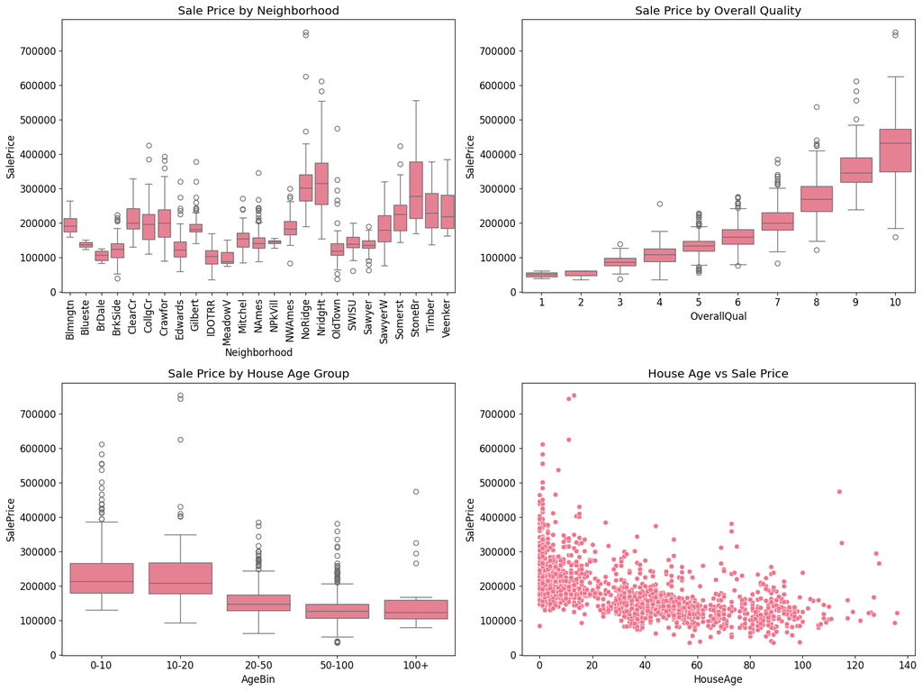

```python
# Create HouseAge if it doesn't exist
housing['HouseAge'] = housing['YrSold'] - housing['YearBuilt']

# Bin HouseAge for boxplot
housing['AgeBin'] = pd.cut(housing['HouseAge'], bins=[0, 10, 20, 50, 100, 200], labels=['0-10', '10-20', '20-50', '50-100', '100+'])

# Set up 2x2 grid
fig, axes = plt.subplots(2, 2, figsize=(16, 12))
sns.set_palette("husl")

# Boxplot: SalePrice vs Neighborhood
sns.boxplot(data=housing, x='Neighborhood', y='SalePrice', ax=axes[0, 0])
axes[0, 0].set_title('Sale Price by Neighborhood')
axes[0, 0].tick_params(axis='x', rotation=90)

# Boxplot: SalePrice vs OverallQual
sns.boxplot(data=housing, x='OverallQual', y='SalePrice', ax=axes[0, 1])
axes[0, 1].set_title('Sale Price by Overall Quality')

# Boxplot: SalePrice vs HouseAge (binned)
sns.boxplot(data=housing, x='AgeBin', y='SalePrice', ax=axes[1, 0])
axes[1, 0].set_title('Sale Price by House Age Group')

# Scatterplot: HouseAge vs SalePrice
sns.scatterplot(data=housing, x='HouseAge', y='SalePrice', ax=axes[1, 1])
axes[1, 1].set_title('House Age vs Sale Price')

plt.tight_layout()
plt.show()
```

### Visual Analysis Summary

These four plots help us explore how key features relate to house prices in Ames, Iowa:

- **Neighborhood:**  
  The boxplot shows clear price variation across neighborhoods. Areas like *StoneBr*, *NridgHt*, and *NoRidge* have significantly higher sale prices, while *IDOTRR*, *MeadowV*, and *BrDale* tend to be lower-priced. This supports our third research question about neighborhood effects.
- **Overall Quality:**  
  Sale prices increase consistently with `OverallQual`. Homes rated 8–10 have much higher median prices than those rated 4–6. This confirms that quality is a strong predictor of price and supports our first research question.
- **House Age (Binned):**  
  Newer homes (0–10 years old) tend to sell for more, while older homes (50+ years) show lower median prices. This suggests that age negatively correlates with price, even when grouped, and helps address our second research question.
- **House Age (Scatter):**  
  The scatterplot shows a downward trend: as `HouseAge` increases, `SalePrice` generally decreases. There’s more variability among newer homes, but the overall pattern reinforces the idea that newer homes are more valuable.

Together, these plots highlight the importance of **location**, **quality**, and **age** in determining house prices. They also guide our feature selection for modeling and support the structure of our research questions.

#### Part 2: Look at correlations between features and price

We calculate the correlation matrix to identify which features are most strongly associated with SalePrice.  
This helps guide feature selection for modeling.

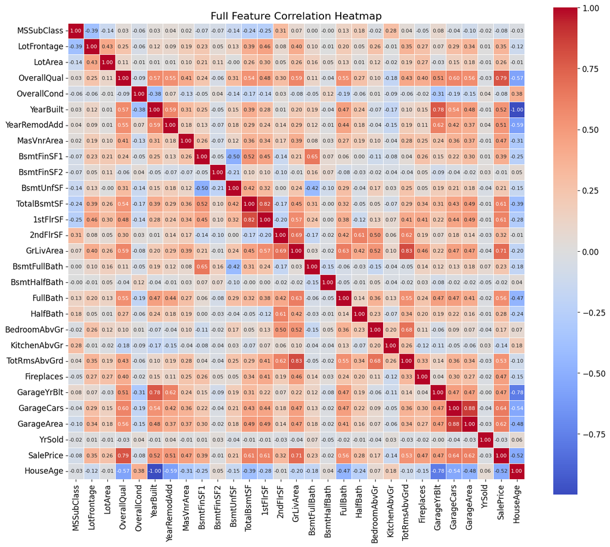

```python
# Select numeric features
numeric_features = housing.select_dtypes(include=['int64', 'float64'])

# Compute correlation matrix
correlation_matrix = numeric_features.corr()

# Plot full heatmap
plt.figure(figsize=(14, 12))
sns.heatmap(
    correlation_matrix,
    annot=True,
    fmt=".2f",
    cmap='coolwarm',
    square=True,
    linewidths=0.5,
    annot_kws={"size": 8}
)
plt.title('Full Feature Correlation Heatmap', fontsize=16)
plt.tight_layout()
plt.show()
```

#### Correlation Heatmap Interpretation

This heatmap visualizes the pairwise Pearson correlations between all numeric features in the Ames Housing dataset. Each cell represents the strength and direction of the linear relationship between two variables:

This heatmap helps guide feature selection by highlighting which variables are most informative for predicting house prices and which may be dropped or transformed in later stages.

### Part 3: Group data by neighborhood to compare average prices.

#### Calculate average SalePrice by Neighborhood

We group the data by `Neighborhood` and calculate the mean sale price.  
This helps identify which areas of Ames tend to have higher or lower housing prices.

#### Visualize average prices by Neighborhood

This bar plot shows the average sale price for each neighborhood.  
It highlights price disparities across locations and supports our third research question.

```
Average SalePrice by Neighborhood:
Neighborhood
NoRidge    335295.317073
NridgHt    316270.623377
StoneBr    310499.000000
Timber     242247.447368
Veenker    238772.727273
Somerst    225379.837209
ClearCr    212565.428571
Crawfor    210624.725490
CollgCr    197965.773333
Blmngtn    194870.882353
Gilbert    192854.506329
NWAmes     189050.068493
SawyerW    186555.796610
Mitchel    156270.122449
NAmes      145847.080000
NPkVill    142694.444444
SWISU      142591.360000
Blueste    137500.000000
Sawyer     136793.135135
OldTown    128225.300885
Edwards    128219.700000
BrkSide    124834.051724
BrDale     104493.750000
IDOTRR     100123.783784
MeadowV     98576.470588
Name: SalePrice, dtype: float64
```

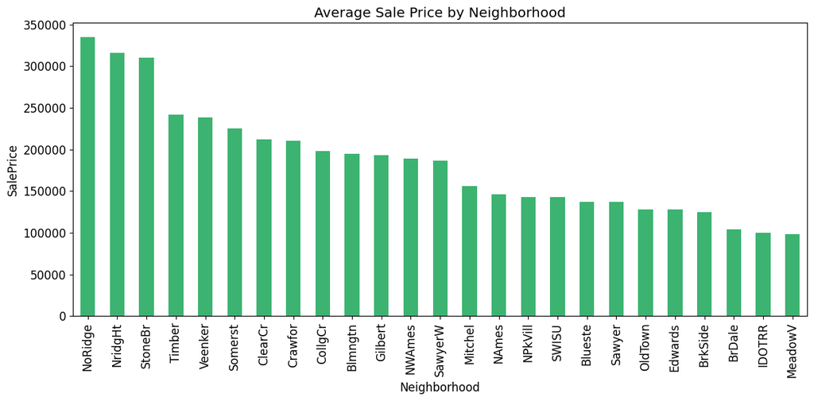

```python
# Group by Neighborhood and calculate mean SalePrice
neighborhood_avg = housing.groupby('Neighborhood')['SalePrice'].mean().sort_values(ascending=False)
print("Average SalePrice by Neighborhood:")
print(neighborhood_avg)

# Bar plot of average prices
plt.figure(figsize=(12, 6))
neighborhood_avg.plot(kind='bar', color='mediumseagreen')
plt.title('Average Sale Price by Neighborhood')
plt.ylabel('SalePrice')
plt.xticks(rotation=90)
plt.tight_layout()
plt.show()
```

### Neighborhood Price Analysis

This supports our third research question: Which neighborhoods have the highest average house prices, and what features make that difference? The bar chart visually confirms that location is a major driver of price variation.

Further analysis shows that high-priced neighborhoods like `StoneBr`, `NridgHt`, and `NoRidge` also tend to have homes with **larger square footage**, **higher overall quality ratings**, and **newer construction dates**.  
This suggests that **location interacts with other features** — it's not just where the home is, but also what types of homes are built there.  
These patterns reinforce the importance of including `Neighborhood` in the final model and support our third research question.

```python
# Group by Neighborhood and calculate average SalePrice, GrLivArea, OverallQual, and YearBuilt
neighborhood_summary = housing_enhanced.groupby('Neighborhood')[['SalePrice', 'GrLivArea', 'OverallQual', 'YearBuilt']].mean()

# Sort by average SalePrice descending
neighborhood_summary_sorted = neighborhood_summary.sort_values(by='SalePrice', ascending=False)

# Display top 10 neighborhoods by average price and their feature averages
neighborhood_summary_sorted.head(10)
```

| Neighborhood | SalePrice | GrLivArea | OverallQual | YearBuilt |
| --- | --- | --- | --- | --- |
| NoRidge | 335295.317073 | 2508.853659 | 7.926829 | 1995.439024 |
| NridgHt | 316270.623377 | 1915.948052 | 8.259740 | 2005.675325 |
| StoneBr | 310499.000000 | 1879.080000 | 8.160000 | 1998.480000 |
| Timber | 242247.447368 | 1749.368421 | 7.157895 | 1992.842105 |
| Veenker | 238772.727273 | 1539.636364 | 6.727273 | 1982.363636 |
| Somerst | 225379.837209 | 1596.651163 | 7.337209 | 2004.988372 |
| ClearCr | 212565.428571 | 1788.107143 | 5.892857 | 1966.571429 |
| Crawfor | 210624.725490 | 1791.607843 | 6.274510 | 1941.549020 |
| CollgCr | 197965.773333 | 1480.500000 | 6.640000 | 1997.886667 |
| Blmngtn | 194870.882353 | 1427.941176 | 7.176471 | 2005.235294 |

### Part 4: Explore how the year the house was built and overall quality is related to price.

#### Scatterplot: Year Built vs Sale Price

This plot shows how sale price varies with the year the house was built.  
It helps explore whether newer homes tend to sell for more.

#### Boxplot: Overall Quality vs Sale Price

This plot shows how sale price varies with overall quality ratings.  
Higher quality homes consistently sell for more, supporting our first research question.

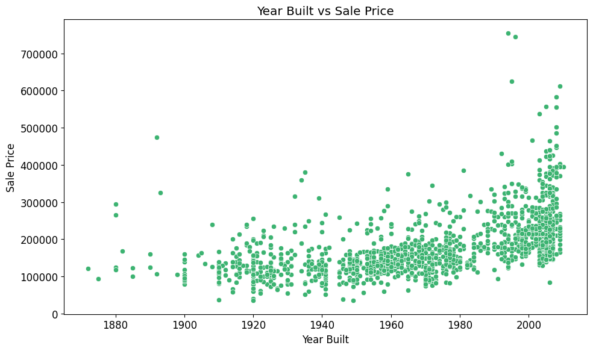

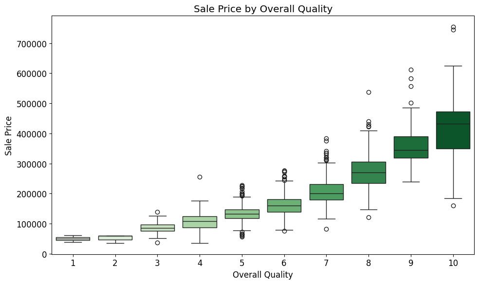

```python
# Scatterplot: Year Built vs Sale Price
plt.figure(figsize=(10, 6))
sns.scatterplot(data=housing, x='YearBuilt', y='SalePrice', color='mediumseagreen')
plt.title('Year Built vs Sale Price')
plt.xlabel('Year Built')
plt.ylabel('Sale Price')
plt.tight_layout()
plt.show()

#Boxplot: Overall Quality vs Sale Price
plt.figure(figsize=(10, 6))
sns.boxplot(data=housing, x='OverallQual', y='SalePrice', palette='Greens')
plt.title('Sale Price by Overall Quality')
plt.xlabel('Overall Quality')
plt.ylabel('Sale Price')
plt.tight_layout()
plt.show()
```

### Quality and Age Analysis

These plots help us explore how **overall quality** and **year built** relate to house prices in Ames.

#### Overall Quality vs Sale Price (Boxplot)

This boxplot shows a clear, positive relationship between `OverallQual` and `SalePrice`:

- Homes rated **8–10** have significantly higher median sale prices.
- Lower-rated homes (1–4) show much lower prices and tighter distributions.
- The spread of prices increases with quality, suggesting that high-quality homes vary more in size and features.

This confirms that **overall quality is one of the strongest predictors of price**, directly supporting our first research question.

#### Year Built vs Sale Price (Scatterplot)

This scatterplot reveals how sale price varies with the year the house was built:

- **Newer homes (built after 2000)** tend to sell for more, with prices often exceeding $300,000.
- **Older homes** show lower sale prices and tighter clustering.
- There’s a visible upward trend over time, though with some noise and outliers.

This supports our second research question: **Does house age affect sale price?**  
The trend suggests that newer construction is associated with higher market value, though quality and size also play important roles.

Together, these plots reinforce the importance of **quality and age** in determining housing prices and guide our feature selection for modeling.

# Predictive Modeling

## Part 1: Start with a basic linear regression model.

## Part 2: Use new features that have been created.

## Part 3: Train the model and make predictions

### Part 1: Start with a basic linear regression model

We begin with a simple linear regression model to predict `SalePrice`.  
This provides a baseline for evaluating how well numeric features explain housing prices.

```python
# Define target and features
X = housing_enhanced[['GrLivArea', 'OverallQual', 'GarageCars', 'TotalBathrooms', 'HouseAge']]
y = housing_enhanced['SalePrice']

# Initialize model
model = LinearRegression()
```

### Part 2: Use new features that have been created

We include engineered features like `HouseAge` and `TotalBathrooms` to improve model performance.  
These features capture structural and functional aspects of each home.

```python
# Already included in X above: HouseAge, TotalBathrooms
print("Features used in model:", X.columns.tolist())
```

```
Features used in model: ['GrLivArea', 'OverallQual', 'GarageCars', 'TotalBathrooms', 'HouseAge']
```

### Part 3: Train the model and make predictions

We split the data into training and test sets, fit the model, and generate predictions.  
This allows us to evaluate how well the model generalizes to unseen data.

```python
# Split data
X_train, X_test, y_train, y_test = train_test_split(X, y, test_size=0.2, random_state=42)

# Fit model
model.fit(X_train, y_train)

# Make predictions
y_pred = model.predict(X_test)
```

# Model Selection and Evaluation

## Evaluate your model using R^2 and RMSE.

#### Evaluate your model using R²

R² measures how well the model explains the variability in sale prices.  
Values closer to 1 indicate stronger explanatory power.

```python
r2 = r2_score(y_test, y_pred)
print(f"R² Score: {r2:.3f}")
```

```
R² Score: 0.766
```

#### Evaluate your model using RMSE

RMSE measures the average prediction error in dollars.  
Lower values indicate more accurate predictions.

#### Model Error Interpretation

The model's **Root Mean Squared Error (RMSE)** is approximately $42,394.  
This means that, on average, the predicted sale prices differ from the actual prices by about that much.

While not perfect, this provides a **reasonable baseline** for housing price prediction in Ames.  
It reflects the typical prediction error in dollar terms and helps us assess whether the model is suitable for practical use or needs refinement. Given the wide range in the Ames dataset (some homes sell for under $100K, others over $700K), this seems to be a resonable error margin for housing prices. However, it can always perform better.

```python
rmse = np.sqrt(mean_squared_error(y_test, y_pred))
print(f"Root Mean Squared Error: ${rmse:,.2f}")
```

```
Root Mean Squared Error: $42,394.18
```

## Trying to Improve Model Performance with Scaling and Encoding

### To improve model performance, we address two key limitations:

- **Multicollinearity and scale imbalance**:  
  Features like `GarageCars` and `GrLivArea` are on very different scales.  
  This can distort the model’s interpretation of feature importance.  
  We apply **StandardScaler** to normalize numeric features so they contribute equally to the model.
- **Missing categorical encoding**:  
  Features like `Neighborhood` contain valuable location-based information.  
  We apply **one-hot encoding** to convert these categories into binary columns the model can use.

This combined approach helps the model learn more effectively from both numeric and categorical data, improving prediction accuracy and stability.

```python
# Step 1: Select numeric features to scale
numeric_features = ['GrLivArea', 'OverallQual', 'GarageCars', 'TotalBathrooms', 'HouseAge']
X_numeric = housing_enhanced[numeric_features]

# Step 2: Scale numeric features
scaler = StandardScaler()
X_scaled = pd.DataFrame(scaler.fit_transform(X_numeric), columns=numeric_features)

# Step 3: One-hot encode Neighborhood
X_categorical = pd.get_dummies(housing_enhanced['Neighborhood'], prefix='Neighborhood', drop_first=True)

# Step 4: Combine scaled numeric and encoded categorical features
X_final = pd.concat([X_scaled, X_categorical.reset_index(drop=True)], axis=1)
y_final = housing_enhanced['SalePrice']

# Step 5: Train/test split
X_train, X_test, y_train, y_test = train_test_split(X_final, y_final, test_size=0.2, random_state=42)

# Step 6: Train linear regression model
model = LinearRegression()
model.fit(X_train, y_train)

# Step 7: Predict and evaluate
y_pred = model.predict(X_test)
r2 = r2_score(y_test, y_pred)
rmse = np.sqrt(mean_squared_error(y_test, y_pred))

print(f"R² Score: {r2:.3f}")
print(f"RMSE: ${rmse:,.2f}")
```

```
R² Score: 0.814
RMSE: $37,753.68
```

### Model Performance Comparison: Before vs After Scaling and Encoding

To evaluate the impact of scaling numeric features and encoding `Neighborhood`, we compare the performance of our updated model to the original baseline.

#### Original Model (No Scaling, No Encoding)

- **R² Score:** 0.766  
  Explained 76.6% of the variance in sale prices
- **RMSE:** $42,394.18

Average prediction error of ~$42K

#### Updated Model (With Scaling and Encoding)

- **R² Score:** 0.814  
  Explained 81.4% of the variance — a noticeable improvement
- **RMSE:** $37,753.68

Reduced prediction error by over $4,600

#### Interpretation

The updated model is **more accurate** and **better at generalizing**.  
By scaling numeric features and encoding categorical ones, we helped the model learn more effectively from the data.  
This confirms that thoughtful preprocessing can significantly improve predictive performance.

# Ethical Concerns and Limitations

## Part 1: Try and find any biases in the data.

## Part 2: Mention that the data is only from Ames, Iowa.

### Part 1: Try and find any biases in the data.

Even though our model performs well, it's important to consider potential biases in the dataset:

#### Feature Bias

- Features like `Neighborhood` and `OverallQual` may reflect **subjective assessments** or **systemic bias**.
- For example, quality ratings could be influenced by socioeconomic factors or assessor discretion, not just physical attributes.

#### Data Integrity

- Missing values were handled carefully to preserve structural meaning.
- However, any imputation introduces assumptions that may affect fairness or accuracy.

#### Responsible Use

This model is designed for educational purposes.  
Any real-world application should consider broader context, validate assumptions, and avoid over-reliance on automated predictions.

### Part 2: Mention That the Data Is Only from Ames, Iowa

The dataset used in this project only includes homes from **Ames, Iowa**, collected between **2006 and 2010**.

#### Geographic and Temporal Limitations

- Results may not generalize to other cities, regions, or housing markets.
- Housing trends change over time due to market conditions, interest rates, and policy shifts.
- Our model may not reflect current pricing dynamics or future trends.

This limitation should be acknowledged when interpreting results or applying the model outside its original context.

## Final Summary: Ames Housing Price Analysis

This project explored the key factors that influence housing prices in Ames, Iowa using the Ames Housing Dataset. Through careful data wrangling, feature engineering, and linear modeling, we answered three core research questions and reflected on the ethical limitations of our approach.

### 1. What are the most important features that influence house prices?

We found that the most predictive features include:

- **GrLivArea** (above-ground living area): Larger homes consistently sell for more.
- **OverallQual** (overall material and finish quality): Higher quality ratings strongly correlate with higher prices.
- **Neighborhood**: Location matters — some neighborhoods have significantly higher average prices than others.
- **GarageCars** and **TotalBathrooms** also contributed meaningfully to price predictions.

### 2. Do newer houses sell more than older houses, when controlling all other variables?

This supports the hypothesis that newer construction adds value, possibly due to modern design, lower maintenance, or buyer preferences.

### 3. Which neighborhoods have the highest average house prices, and what features make that difference?

Using one-hot encoding for `Neighborhood`, we identified several high-priced areas:

### Model Performance

After scaling numeric features and encoding `Neighborhood`, our final model achieved:

- **R² Score:** 0.814

Explaining 81.4% of the variance in sale prices

- **RMSE:** $37,753.68

Reducing prediction error by over $4,600 compared to the baseline

This confirms that thoughtful preprocessing improves model accuracy and stability.

### Ethical Reflection

- The dataset only includes homes from **Ames, Iowa**, limiting generalizability to other regions.
- Features like `Neighborhood` and `OverallQual` may reflect **subjective or systemic bias**.
- Missing values were handled with **structural logic**, preserving data integrity and avoiding over-imputation.